# pres_Uncertainity slides

## Control and estimation under uncertainity:

### MEC 560: Advaced control systems

#### Vivek Yadav

## Recap

- State space representation
- Controllability and Pole-placement for different control applications
- Optimal control formulation
- Linear quadratic regulator (LQR) control formulation (first variance principles)
- Dynamic programming for LQR
  - Path planning
  - LQR using dynamic programming
- Multiple shooting
- Direct collocation
- Observer design

All techniques above assume a perfect model of the system.

## Types of uncertainities

1. Parametric uncertainity
2. Actuator uncertainity
3. Modeling uncertainity
4. Measurement uncertainity

All the uncertainities can result in erroneous control calculation and undesired system behavior.

## 1. Parametric uncertainity

Uncertainity where model parameters are not accurately known.

### Approximate system:

$$ \dot{X} = AX + Bu $$

with measurements

$$ Y = CX. $$

### Actual system:

$$ \dot{X} = (A+ \Delta A) X + (B + \Delta B) u $$

with measurements,

$$ y = (C+ \Delta C) X $$

## 2. Actuator uncertainity

Uncertainity where there is error between commanded and applied control to the system

### Approximate system:

$$ \dot{X} = AX + Bu $$

with measurements

$$ Y = CX. $$

### Actual system:

$$ \dot{X} = A X + B ( u + \delta u) $$

with measurements, $$ y =C X$$

## 3. Modeling uncertainity

- Uncertainity where one or other phenomena was completely ignored.
- Linearization errors
- Dynamics change due to wear and tear, added load etc.

### Approximate system:

$$ \dot{X} = AX + Bu $$

with measurements

$$ Y = CX. $$

### Actual system:

$$ \dot{X} = A X + B u + f(X,u) $$

with measurements,

$$ y =C X +g(X,u) $$

## 4. Measurement uncertainity

- Measurements have errors due to noise in the sensor

### Approximate system:

$$ \dot{X} = AX + Bu $$

with measurements

$$ Y = CX. $$

### Actual system:

$$ \dot{X} = A X + B u $$

with measurements, $$ y =C X + \nu $$

### Control/estimation under uncertainity: Two approaches

##### 1. Model uncertainity as gaussian process

- Kalman filter
- LQG control

##### 2. Choose control to minimize sesitivity to errors.

- H2 control
- H-\( \infty \) control

### Kalman filter

- Also called Linear Quadratic Estimator, is observability equivalent of Linear Quadratic Regulator.
- Find the states that satisfy the system dyanmics and measurement
- Originally posed as a least-square problem, to minimize difference between state estimates and measurement, while satisfying system dynamics.
- Assumes Gaussian distribution, optimal ONLY if the underlying distribution is Gaussian.
- Updated based on Bayes' rule.

### Kalman filter: Main idea

- Estimate future states based on system dynamics
- Update state estimates after getting measurement
- Find gain that minimizes error between true expected state and estimated state.

[figure not shown]

### Bayesian inference

Bayesian inference is based on Bayes theorem, and gives probability of an event based on features that may be related to an event.

- Bayes' rule

$$ P(A|B) = \frac{P(B|A) P(A)}{P(B)}. $$

- Another form

$$ P(A|B) = \frac{P(B|A) P(A)}{P(B|A) P(A) + P(B| \neg A) P(\neg A)} , $$

- If the event \( A \) can take multiple values say \( A_i \) for \( i : 1 \rightarrow N \).

$$ P(A|B) = \frac{P(B|A) P(A)}{ \sum_{i=1}^N P(B|A_i) P(A_i) } , $$

### Example 1: Cancer testing

Say we have a test for cancer that is 99% accurate, i.e. given a person has cancer, the test gives a positive test 99% of the time. This is also referred as the true-positive rate or sensitivity. Further, if a person does not have cancer, the test gives a negative result 98% of the time, or the true negative rate/specificity is 98%. Knowing that cancer is a rare disease, and only 1.5% of the population has it, if the test comes back positive for some individual, what is the probaility that the individual actually has cancer? Bayes' rule is given by,

$$ P(A|B) = \frac{P(B|A) P(A)}{P(B|A) P(A) + P(B| \neg A) P(\neg A)} , $$

#### Solution:

We wish to determine \( P(C|+) \), where C stands for cancer, NC stands for no cancer, - stands for negative test result, and + stands for a positive test result. The given information about cancer and test can now be written as,

- Sensitivity = 99%, therefore, \( P( + | C ) = .99\).
- Specivity = 98%, therefore, \( P( - | NC ) = .98\).
- Probability of cancer = 0.015, \( P(C) = 0.015 \).

Using Bayes rule,

$$ P(C|+) = \frac{P(+|C) P(C)}{P(+|C) P(C) + P(+| NC) P(NC)} , $$

### Example 2: Baysean estimation (robot localization)

- locations of buildings (red or green) in the world known
- Accurate sensors to detect the color of the building adjacent to the robot
- Locate the robot, given the robot senses green.
- What is the probability distribution of robot's position after measurement?

[figure not shown]

$$ P(X)^- = \left[ \begin{array}{cccccccccc} 0.1 & 0.1 & 0.1 & 0.1 & 0.1 & 0.1 & 0.1 & 0.1 & 0.1 & 0.1 \end{array} \right] $$

$$ P(X)^- = \left[ \begin{array}{cccccccccc} 0.1 & 0.1 & 0.1 & 0.1 & 0.1 & 0.1 & 0.1 & 0.1 & 0.1 & 0.1 \end{array} \right] $$$$ P_g(X)= P(g|X)= \left[ \begin{array}{cccccccccc} 0 & 1/3 & 1/3 & 0 & 0 & 0 & 1/3 & 0 & 0 & 0 \end{array} \right] $$$$P(X)^+ = P(X|g) = \frac{P(g|X)P(X)^-}{P(g)} = \frac{P(g|X)P(X)}{\sum_{i=1}^N P(g|X_i)P(X_i) } $$$$ P(X)^+ = P(X|g) = \frac{\left[ \begin{array}{cccccccccc} 0 & 1/3 & 1/3 & 0 & 0 & 0 & 1/3 & 0 & 0 & 0 \end{array} \right] \circ \left[ \begin{array}{cccccccccc} 0.1 & 0.1 & 0.1 & 0.1 & 0.1 & 0.1 & 0.1 & 0.1 & 0.1 & 0.1 \end{array} \right] }{\sum \left( \left[ \begin{array}{cccccccccc} 0 & 1/3 & 1/3 & 0 & 0 & 0 & 1/3 & 0 & 0 & 0 \end{array} \right] \circ \left[ \begin{array}{cccccccccc} 0.1 & 0.1 & 0.1 & 0.1 & 0.1 & 0.1 & 0.1 & 0.1 & 0.1 & 0.1 \end{array} \right] \right)} $$$$ P(X)^+ = P(X|g) = \left[ \begin{array}{cccccccccc} 0 & 1/3 & 1/3 & 0 & 0 & 0 & 1/3 & 0 & 0 & 0 \end{array} \right]$$

*Note: The process of multiplying functions and adding them up is also called convolution*

- Location certainity after measurement.
- What is the probability if the robot moves 1 step right?

$$ P(X)^+ = P(X|g) = \left[ \begin{array}{cccccccccc} 0 & 1/3 & 1/3 & 0 & 0 & 0 & 1/3 & 0 & 0 & 0 \end{array} \right]$$

[figure not shown]

- New prior probability
- Sense again, what is the probability distribution of robot's location now?

[figure not shown]

$$ P(X)^- = \left[ \begin{array}{cccccccccc} 0 & 0 & 1/3 & 1/3 & 0 & 0 & 0 & 1/3 & 0 & 0 \end{array} \right] $$

$$P(X)^+ = P(X|g) = \frac{P(g|X)P(X)^-}{P(g)} = \frac{P(g|X)P(X)}{\sum_{i=1}^N P(g|X_i)P(X_i) } $$$$ P(X)^+ = \frac{ \left[ \begin{array}{cccccccccc} 0 & 0 & 1/3 & 1/3 & 0 & 0 & 0 & 1/3 & 0 & 0 \end{array} \right] \circ \left[ \begin{array}{cccccccccc} 0 & 1/3 & 1/3 & 0 & 0 & 0 & 1/3 & 0 & 0 & 0\end{array} \right] }{\sum \left( \left[ \begin{array}{cccccccccc} 0 & 0 & 1/3 & 1/3 & 0 & 0 & 0 & 1/3 & 0 & 0 \end{array} \right] \circ \left[ \begin{array}{cccccccccc} 0 & 1/3 & 1/3 & 0 & 0 & 0 & 1/3 & 0 & 0 & 0\end{array} \right] \right)} $$$$ P(X)^+ = \left[ \begin{array}{cccccccccc} 0 & 0 & 1 & 0 & 0 & 0 & 0 & 0 & 0 & 0 \end{array} \right] $$

- Probability distribution after 2 step

$$ P(X)^+ = \left[ \begin{array}{cccccccccc} 0 & 0 & 1 & 0 & 0 & 0 & 0 & 0 & 0 & 0 \end{array} \right] $$

[figure not shown]

### Example 2: Baysean estimation (robot localization, scenario 2)

- What is the probability after measurement?

[figure not shown]

$$ P(X)^- = \left[ \begin{array}{cccccccccc} 0.1 & 0.1 & 0.1 & 0.1 & 0.1 & 0.1 & 0.1 & 0.1 & 0.1 & 0.1 \end{array} \right] . $$

- Bayes' rule

$$P(X)^+ = P(X|g) = \frac{P(g|X)P(X)^-}{P(g)} = \frac{P(g|X)P(X)}{\sum_{i=1}^N P(g|X_i)P(X_i) } $$$$ P(X)^+ = P(X|g) = \left[ \begin{array}{cccccccccc} 0 & 1/3 & 1/3 & 0 & 0 & 0 & 1/3 & 0 & 0 & 0 \end{array} \right]$$

[figure not shown]

- After movement

$$ P(X)^- = \left[ \begin{array}{cccccccccc} 0 & 0 & 1/3 & 1/3 & 0 & 0 & 0 & 1/3 & 0 & 0 \end{array} \right] $$

[figure not shown]

- After sensing,

$$P(X)^+ = P(X|r) = \frac{P(r|X)P(X)^-}{P(r)} = \frac{P(r|X)P(X)}{\sum_{i=1}^N P(r|X_i)P(X_i) } $$$$ P_r(X) =P(r|X)= \left[ \begin{array}{cccccccccc} 1/7 & 0 & 0 & 1/7 & 1/7 & 1/7 & 0 & 1/7 & 1/7 & 1/7 \end{array} \right] $$

$$ P(X)^+ = \frac{ \left[ \begin{array}{cccccccccc} 0 & 0 & 0 & 1/21 & 0 & 0 & 0 & 1/21 & 0 & 0 \end{array} \right] }{\sum \left( \left[ \begin{array}{cccccccccc} 0 & 0 & 0 & 1/21 & 0 & 0 & 0 & 1/21 & 0 & 0 \end{array} \right] \right)} = \frac{ \left[ \begin{array}{cccccccccc} 0 & 0 & 0 & 1/21 & 0 & 0 & 0 & 1/21 & 0 & 0 \end{array} \right] }{2/21} $$$$ P(X)^+ = \left[ \begin{array}{cccccccccc} 0 & 0 & 0 & 1/2 & 0 & 0 & 0 & 1/2 & 0 & 0 \end{array} \right] $$

$$ P(X)^+ = \left[ \begin{array}{cccccccccc} 0 & 0 & 0 & 1/2 & 0 & 0 & 0 & 1/2 & 0 & 0 \end{array} \right] $$

[figure not shown]

## Baysian rule for Gaussian distributions

- We could combine movement (dynamics) and measurement information by multiplying their corresponding probabilties.
- If the dependent variable is continuous, we use Gaussian (or normal) distribution.

### Gaussian Distributions

- Characterized by a bell-shape curve
- Most physical phenomena follow gaussian-like distributions
- Central limit theorem states that under certain assumptions, mean of random samples drawn from any given distribution converge to a Gaussian/normal distribution when the number of samples become very large.
- Mathematical form of distribution allows us to compute analytical solutions

$$ f(X| \mu, \sigma^2) = \frac{1}{\sqrt{2 \pi \sigma^2}} e^{ - \frac{(X-\mu)^2}{2 \sigma^2}} $$

where, \( \mu \) is the mean and \( \sigma \) is the standard deviation of the distribution.

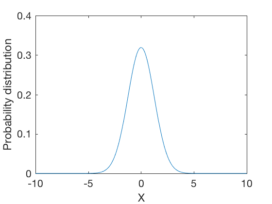

```matlab
clc;close all;clear all

X = -10:0.01:10;
mu = 0;
sigma = 1.25;
f_x = 1/sqrt(2*pi*sigma^2) * exp( -(X-mu).^2/(2*sigma^2) );
figure;
plot(X,f_x)
axis([-10 10 0 .4])
xlabel('X')
ylabel('Probability distribution')
```

### Bayesian rule for Gaussian probabilities

Consider two normal probability distributions given by,

$$ f(X| \mu_1, \sigma_1^2) = \frac{1}{\sqrt{2 \pi \sigma_1^2}} e^{ - \frac{(X-\mu_1)^2}{2 \sigma_1^2}} $$

$$ f(X| \mu_2, \sigma_2^2) = \frac{1}{\sqrt{2 \pi \sigma_2^2}} e^{ - \frac{(X-\mu_2)^2}{2 \sigma_2^2}} $$

The Bayesian probability is given by,

$$ f((X| \mu_1, \sigma_1^2)|(X| \mu_2, \sigma_2^2)) = \frac{f(X| \mu_2, \sigma_2^2) f(X| \mu_2, \sigma_2^2)}{\int_{-\infty}^{\infty}f(X| \mu_2, \sigma_2^2) f(X| \mu_2, \sigma_2^2)dX}$$

$$ f((X| \mu_1, \sigma_1^2)|(X| \mu_2, \sigma_2^2)) = \frac{1}{\sqrt{2 \pi \sigma_1^2}} e^{ - \frac{(X-\mu_1)^2}{2 \sigma_1^2}}\frac{1}{\sqrt{2 \pi \sigma_2^2}} e^{ - \frac{(X-\mu_2)^2}{2 \sigma_2^2}} $$

After significant algebra, the final conditional probability, can be represented as,

$$ f(X| \mu_1, \sigma_1^2) | f(X| \mu_2, \sigma_2^2) = f(X| \mu_{12}, \sigma_{12}^2) = \frac{1}{\sqrt{2 \pi \sigma_{12}^2}} e^{ - \frac{(X-\mu_{12})^2}{2 \sigma_{12}^2}} , $$

where,

$$ \sigma_{12}^2 = \frac{\sigma_1^2 \sigma_2^2}{\sigma_1^2+\sigma_2^2} $$

and

$$ \mu_{12} = \frac{\sigma_1^2 \mu_2 + \sigma_2^2 \mu_1}{\sigma_1^2+\sigma_2^2} . $$

### Gaussian Example 1: combined probability

$$ \sigma_{12}^2 = \frac{\sigma_1^2 \sigma_2^2}{\sigma_1^2+\sigma_2^2}=3.2 $$

and

$$ \mu_{12} = \frac{\sigma_1^2 \mu_2 + \sigma_2^2 \mu_1}{\sigma_1^2+\sigma_2^2}=.66 . $$

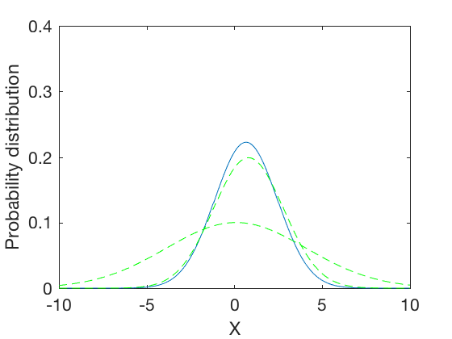

```
\mu_{12} = 0.66, \sigma_{12} = 1.7889
```

```matlab
clc;close all;clear all
X = -10:0.01:10;
mu1 = .8 ; sigma1 = 2;mu2 = .1 ; sigma2 = 4;
mu12 = (sigma1^2*mu2 + sigma2^2*mu1)/(sigma1^2 + sigma2^2);
sigma12 = sqrt((sigma1^2*sigma2^2)/(sigma1^2 + sigma2^2));
display(['\mu_{12} = ' num2str(mu12) ', \sigma_{12} = ' num2str(sigma12)] )
f1 = 1/sqrt(2*pi*sigma1^2) * exp( -(X-mu1).^2/(2*sigma1^2) );
f2 = 1/sqrt(2*pi*sigma2^2) * exp( -(X-mu2).^2/(2*sigma2^2) );
f12 = 1/sqrt(2*pi*sigma12^2) * exp( -(X-mu12).^2/(2*sigma12^2) );
figure;
plot(X,f12,X,f1,'g--',X,f2,'g--');axis([-10 10 0 .4])
xlabel('X');ylabel('Probability distribution')
```

### Gaussian Example 2: combined probability

$$ \sigma_{12}^2 = \frac{\sigma_1^2 \sigma_2^2}{\sigma_1^2+\sigma_2^2}=2 $$

and

$$ \mu_{12} = \frac{\sigma_1^2 \mu_2 + \sigma_2^2 \mu_1}{\sigma_1^2+\sigma_2^2}=0 . $$

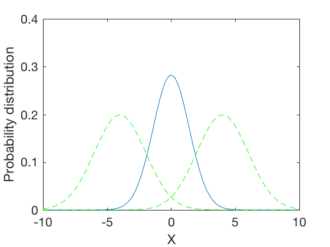

```
\mu_{12} = 0, \sigma_{12} = 1.4142
```

```matlab
clc;close all;clear all
X = -10:0.01:10;
mu1 = -4 ; sigma1 = 2;mu2 = 4 ; sigma2 = 2;
mu12 = (sigma1^2*mu2 + sigma2^2*mu1)/(sigma1^2 + sigma2^2);
sigma12 = sqrt((sigma1^2*sigma2^2)/(sigma1^2 + sigma2^2));
display(['\mu_{12} = ' num2str(mu12) ', \sigma_{12} = ' num2str(sigma12)] )
f1 = 1/sqrt(2*pi*sigma1^2) * exp( -(X-mu1).^2/(2*sigma1^2) );
f2 = 1/sqrt(2*pi*sigma2^2) * exp( -(X-mu2).^2/(2*sigma2^2) );
f12 = 1/sqrt(2*pi*sigma12^2) * exp( -(X-mu12).^2/(2*sigma12^2) );
figure;
plot(X,f12,X,f1,'g--',X,f2,'g--');axis([-10 10 0 .4])
xlabel('X');ylabel('Probability distribution')
```

## Gaussian 2-D distribution

Multivariate distributions involve multiplication of multiple gaussian distributions,

- Example,

[figure not shown]

- multivariate distribution in \( k\) dimensions is represented as,

$$ f(X| \mathbf{\mu}, \mathbf{\Sigma}) = \frac{1}{\sqrt{ (2 \pi)^k |\mathbf{\Sigma}| }} e^{ - \frac{1}{2} (X-\mathbf{\mu})^T \mathbf{\Sigma}^{-1} (X-\mathbf{\mu}) }$$

In the special case when \( K = 2 \), we have

$$ \mathbf{\Sigma} = \left[ \begin{array}{cc} \sigma_X^2 & \sigma_{X,Y} \\ \sigma_{X,Y} & \sigma_Y^2 \end{array} \right] $$

where \( \sigma_{X,Y} \) is the second moment between x- and y- variables.

## Kalman filter 2-D: Example

- Robot localization, Position measurement only

[figure not shown]

- Robot's next location based on velocity for t = 1 .

[figure not shown]

- After movement

[figure not shown]

- After multiplying probabilities

[figure not shown]

## Kalman filters: optimality, maximum likelihood

Reframe linear regression problem as follows,

- determining pameters \( \beta_0\) and \( \beta_1 \) such that the likelihood of a given value \( y \) being of the form \( \beta_0 + \beta_1 X \) is maximized. \( e_i = y_i - (\beta_0+ \beta_1 x_i) \). i.e. likelihood of errors coming from a linear fit are

$$ p(e_i| 0, \sigma^2) = \frac{1}{\sqrt{2 \pi \sigma^2}} e^{ - \frac{(y_i - (\beta_0+ \beta_1 x_i))^2}{2 \sigma^2}} $$

$$ p( e_1, e_2, \dots , e_N ) = \underbrace{\Pi}_{i=1~to~n} p(e_i| 0, \sigma^2)$$

$$ p( e_1, e_2, \dots , e_N ) = \underbrace{\Pi}_{i=1~to~n} p(e_i| 0, \sigma^2) = \underbrace{\Pi}_{i=1~to~n} \frac{1}{\sqrt{2 \pi \sigma^2}} e^{ - \frac{(y_i - (\beta_0+ \beta_1 x_i))^2}{2 \sigma^2}} $$$$ \underbrace{Maximize}_{\beta_0,\beta_1}~log(p( e_1, e_2, \dots , e_N )) = \underbrace{Maximize}_{\beta_0,\beta_1}\sum_{i=1}^N \left(- \frac{(y_i - (\beta_0+ \beta_1 x_i))^2}{2 \sigma^2} - \frac{1}{2}log(2 \pi \sigma^2) \right)$$$$ \underbrace{Minimize}_{\beta_0,\beta_1}\sum_{i=1}^N \left(y_i - (\beta_0+ \beta_1 x_i) \right)^2, $$

- Least square solution is the same as maximum likelihood solution if the errors are distributed normally.

## Particle filters

- Simulation based filters
- Generate several particles as possible locations of the robot
- Measure states for each particle, and weigh each particle by closeness to true measurement.
- Resample so particles with larger weight survive

[figure not shown]

## Particle filter for localization

[figure not shown]